# ProjectAnalysis

Sophie Buysse

2024-07-01

# Goal

The goal of this code is to do all the data cleaning, subsetting, and calculating of differences to prepare for doing statistical analysis. When that is completed, this code will analyze difference in science literacy scores by section and by those students who completed the modelling activity and those who did not. It will also break down science literacy score changes into 9 specific science literacy skills. Finally, it will look for a relationship between group mean science literacy scores and group final presentation scores to identify if students with higher science literacy are better able to present their experimental results and significance.

The data read into this document was anonymized by someone outside the research team before analysis, but they did not exclude any data during the anonymization process.

# Install Packages

```r
library(dplyr)
library(ggplot2)
library(lubridate)
library(lme4)
library(ggpubr)
library(lmerTest)
```

# Filter Data

Filter data by individuals who consented to be in the research study during both the pre and post assessment:

251 students consented to be included in the study from 4 recitation sections.

Exclude any students who completed the pre or post science literacy survey in less than 10 minutes, the time it takes for me to read through all the included text on the survey. Some students took a long time becuase there was no time limit, and if they leave the survey open on their computer the time keeps counting up. left these students in.

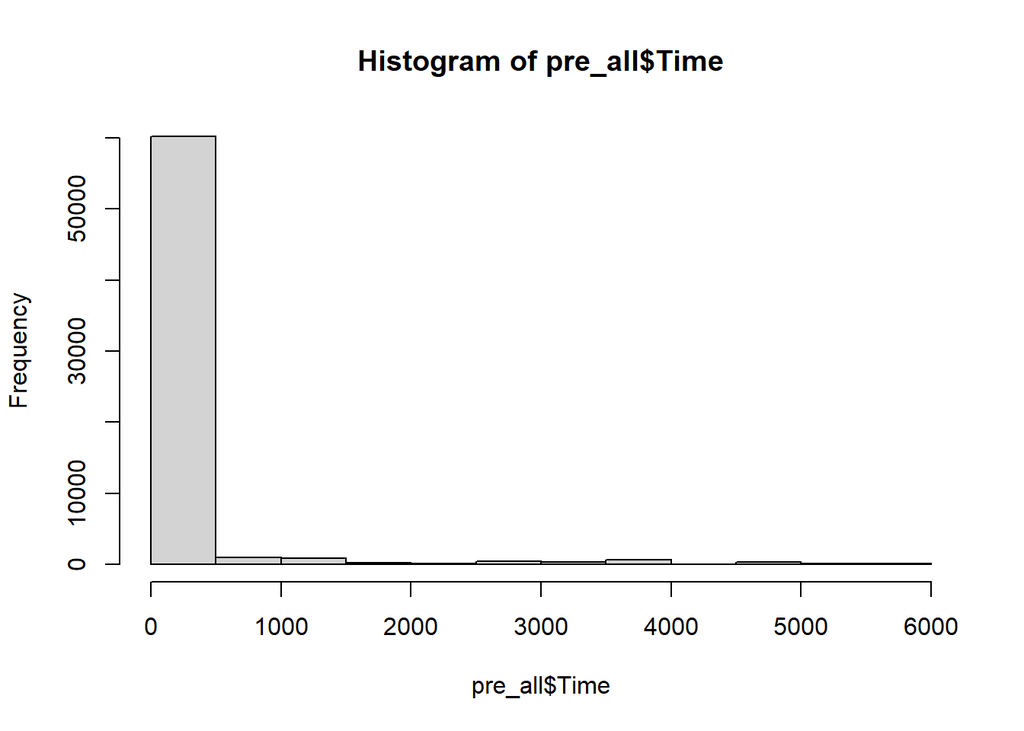

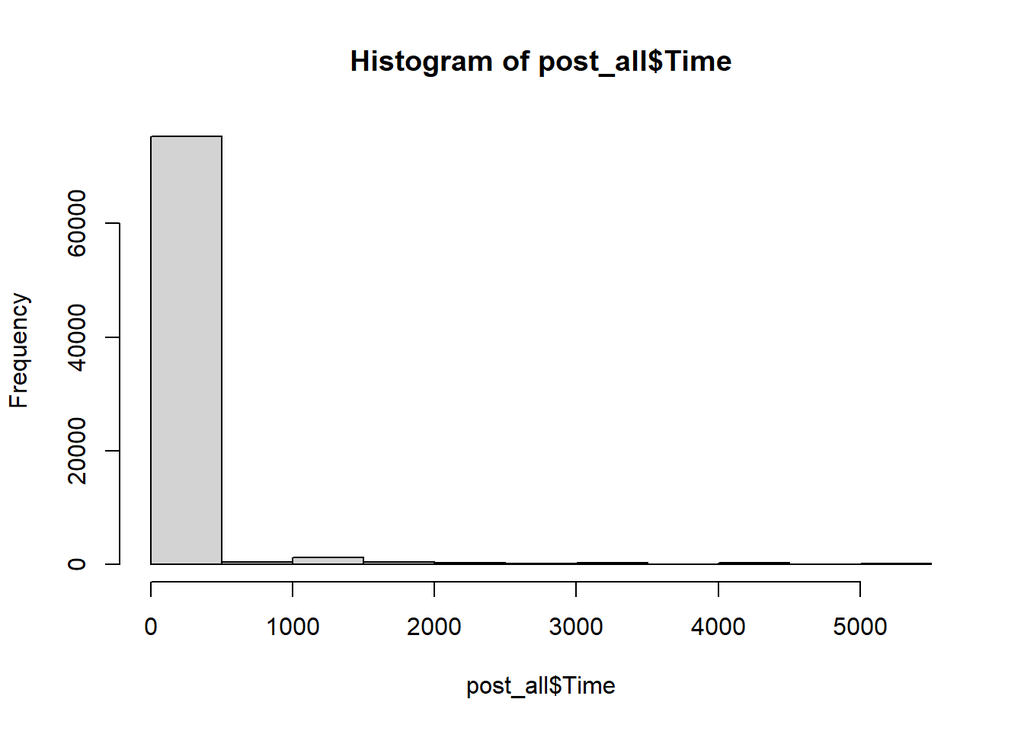

Of the 251 students who consented and took both the pre and the post, 6 of them were too speedy with the pre so they were cut.

# Overall, did modelling impact science literacy?

Calculate Score Percentages

```r
pre_tot$pre_perc <- pre_tot$Score / pre_tot$Out.Of
pre_tot <- pre_tot %>%
  rename(pre_score = Score)
max(pre_tot$pre_score)
```

```
## [1] 28
```

```r
min(pre_tot$pre_score)
```

```
## [1] 3
```

```r
mean(pre_tot$pre_score)
```

```
## [1] 19.65714
```

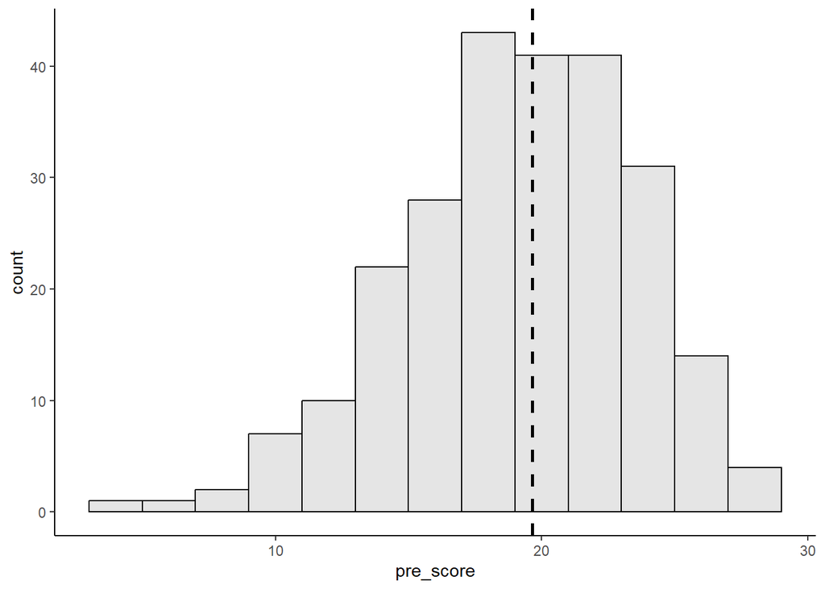

```r
ggplot(pre_tot, aes(x=pre_score))+
  geom_histogram(binwidth=2, color = "black", fill = "grey90")+
  geom_vline(aes(xintercept=mean(pre_score)),
            color="black", linetype="dashed", size=1)+
  theme_classic()
```

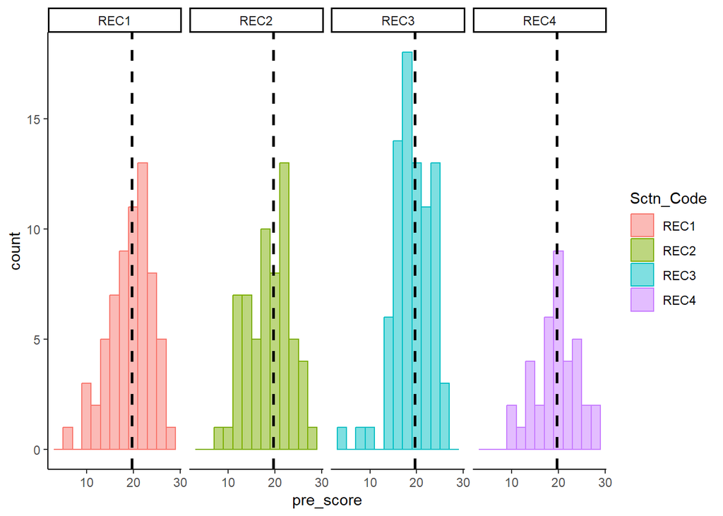

```r
#NOTE: in the below code, the line drawn is the OVERALL MEAN. it is NOT the mean for each section.
ggplot(pre_tot, aes(x=pre_score, ))+
  geom_histogram(binwidth=2, aes(color=Sctn_Code, fill = Sctn_Code), alpha = 0.5, position = "identity")+
  geom_vline(aes(xintercept=mean(pre_score)),
            color="black", linetype="dashed", size=1)+
  facet_grid(. ~ Sctn_Code)+
  theme_classic()
```

```r
pre_tot %>%
  group_by(Sctn_Code) %>%
  summarize(mean_pre = mean(pre_score, na.rm = TRUE), num = n())
```

```
## # A tibble: 4 × 3
##   Sctn_Code mean_pre   num
##   <chr>        <dbl> <int>
## 1 REC1          19.9    65
## 2 REC2          19.2    62
## 3 REC3          19.7    81
## 4 REC4          19.9    37
```

```r
post_tot$post_perc <- post_tot$Score / post_tot$Out.Of
post_tot <- post_tot %>%
  rename(post_score = Score)
max(post_tot$post_score)
```

```
## [1] 28
```

```r
min(post_tot$post_score)
```

```
## [1] 8
```

```r
mean(post_tot$post_score)
```

```
## [1] 20.29084
```

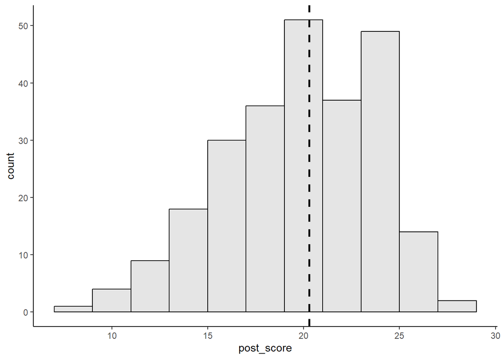

```r
ggplot(post_tot, aes(x=post_score))+
  geom_histogram(binwidth=2, color = "black", fill = "grey90")+
  geom_vline(aes(xintercept=mean(post_score)),
            color="black", linetype="dashed", size=1)+
  theme_classic()
```

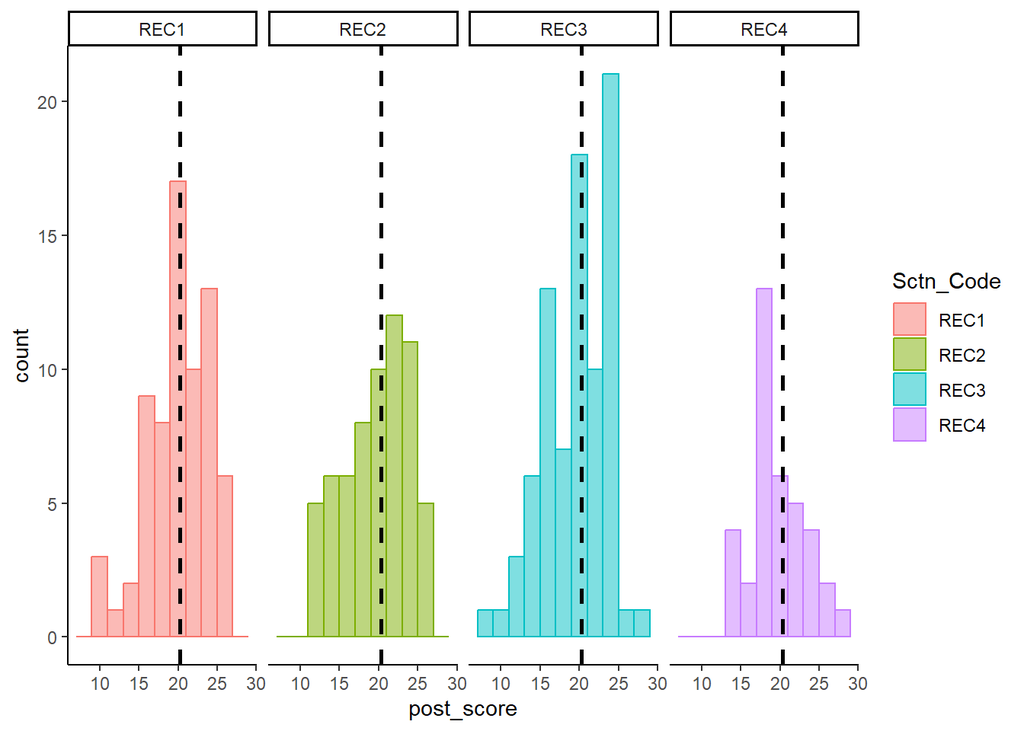

```r
# line drawn is again the overall mean
ggplot(post_tot, aes(x=post_score, ))+
  geom_histogram(binwidth=2, aes(color=Sctn_Code, fill = Sctn_Code), alpha = 0.5, position = "identity")+
  geom_vline(aes(xintercept=mean(post_score)),
            color="black", linetype="dashed", size=1)+
  facet_grid(. ~ Sctn_Code)+
  theme_classic()
```

```r
post_tot %>%
  group_by(Sctn_Code) %>%
  summarize(mean_post = mean(post_score, na.rm = TRUE), num = n())
```

```
## # A tibble: 4 × 3
##   Sctn_Code mean_post   num
##   <chr>         <dbl> <int>
## 1 REC1           20.6    69
## 2 REC2           20.2    63
## 3 REC3           20.1    82
## 4 REC4           20.3    37
```

Summarize difference by section and model completed yes/no

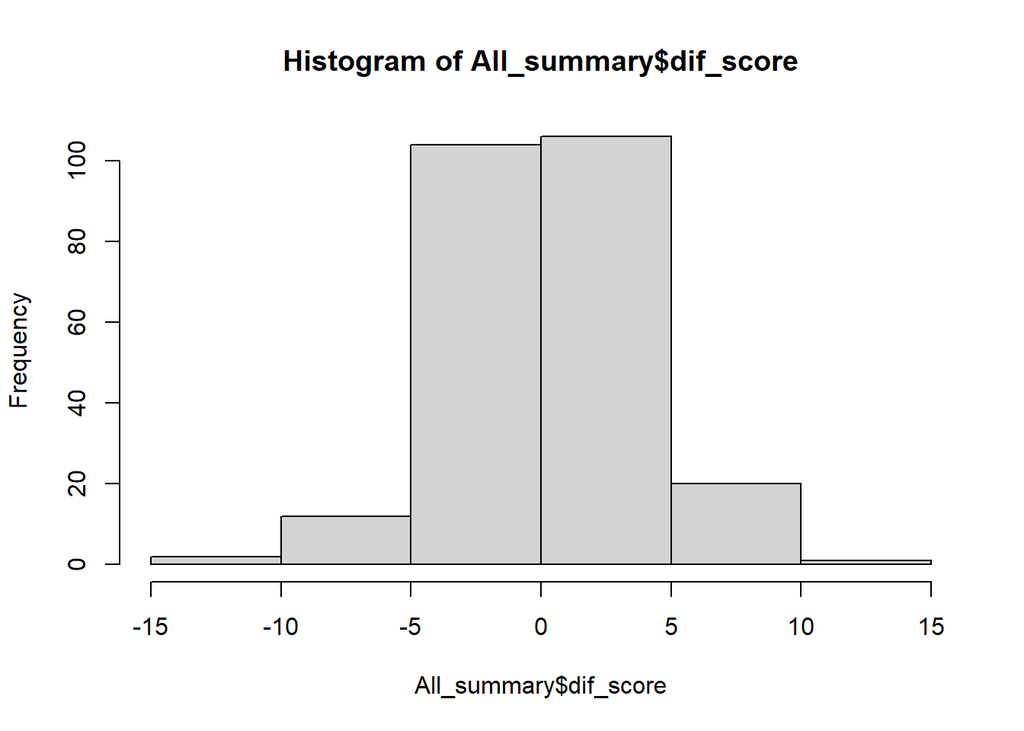

```r
All_summary <- merge(pre_tot, post_tot, by = c("Random_Number", "Out.Of", "Sctn_Code", "Sctn_Id_Code"), all.x = TRUE, all.y = FALSE)
# some folks didn't do pre and post; all.y = FALSE gets rid of the 6 individuals who were too speedy on the pre
All_summary$dif_score <- All_summary$post_score - All_summary$pre_score
All_summary$dif_perc <- All_summary$post_perc - All_summary$pre_perc

# quick look
hist(All_summary$dif_score)
```

```r
# add model information. note: this assumes everyone came to class the day the activity was completed.
All_summary$model <- "no"
All_summary[All_summary$Sctn_Code %in% c("REC2", "REC4"), "model"] <- "yes"
# order factors - do this way so works for all figures
All_summary$model <- factor(All_summary$model, levels = c("yes", "no"))

# summarize by section
All_summary %>%
  group_by(Sctn_Code) %>%
  summarize(mean_dif = mean(dif_score, na.rm = TRUE))
```

```
## # A tibble: 4 × 2
##   Sctn_Code mean_dif
##   <chr>        <dbl>
## 1 REC1         0.831
## 2 REC2         1.08
## 3 REC3         0.469
## 4 REC4         0.378
```